# MPDW Pertemuan 1 - Pemulusan

Vita Rizkyana Anggraeni

## Library / Packages

```r
library("forecast")
```

```r
library("graphics")
library("TTR")
library("TSA")
library("readxl")
library(rio)
```

## Read Data

```r
data <- import("https://raw.githubusercontent.com/vitaarizkyana/PraktikumMPDW/main/Data/MPDW%20Pertemuan%201.xlsx")
str(data)
```

```
## 'data.frame':    520 obs. of  3 variables:
##  $ tanggal: POSIXct, format: "2013-04-15" "2013-04-22" ...
##  $ stock  : num  20.1 20.5 21.2 22 23 ...
##  $ periode: num  1 2 3 4 5 6 7 8 9 10 ...
```

```r
dim(data)
```

```
## [1] 520   3
```

## Eksplorasi Data

Melihat data menggunakan fungsi `View()`, struktur data menggunakan fungsi `str()`, dan dimensi data menggunakan fungsi `dim()`.

```r
View(data)
str(data)
```

```
## 'data.frame':    520 obs. of  3 variables:
##  $ tanggal: POSIXct, format: "2013-04-15" "2013-04-22" ...
##  $ stock  : num  20.1 20.5 21.2 22 23 ...
##  $ periode: num  1 2 3 4 5 6 7 8 9 10 ...
```

```r
dim(data)
```

```
## [1] 520   3
```

Mengubah data agar terbaca sebagai data deret waktu dengan fungsi `ts()` .

```r
data.ts <- ts(data$stock)
```

Menampilkan ringkasan data

```r
summary(data.ts)
```

```
##    Min. 1st Qu.  Median    Mean 3rd Qu.    Max.
##   20.11   35.52   54.77   63.08   80.12  151.55
```

Membuat plot data deret waktu

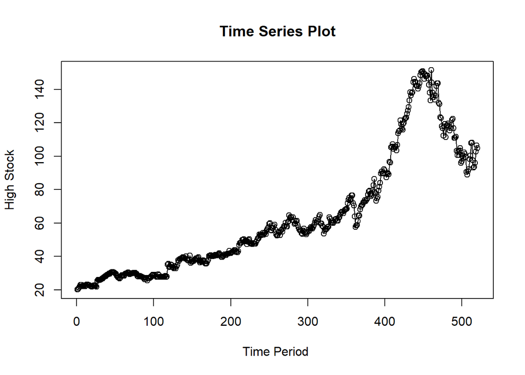

```r
ts.plot(data.ts, xlab="Time Period ", ylab="High Stock",
        main = "Time Series Plot")
points(data.ts)
```

## Single Moving Average & Double Moving Average

### Pembagian Data

Pembagian data latih dan data uji dilakukan dengan perbandingan 80% data latih dan 20% data uji.

```r
#Membagi data latih dan data uji
training <- data[1:416,]
testing <- data[417:520,]
train_ma.ts <- ts(training$stock)
test_ma.ts <- ts(testing$stock)
```

### Eksplorasi Data

Eksplorasi data dilakukan pada keseluruhan data, data latih serta data uji menggunakan plot data deret waktu.

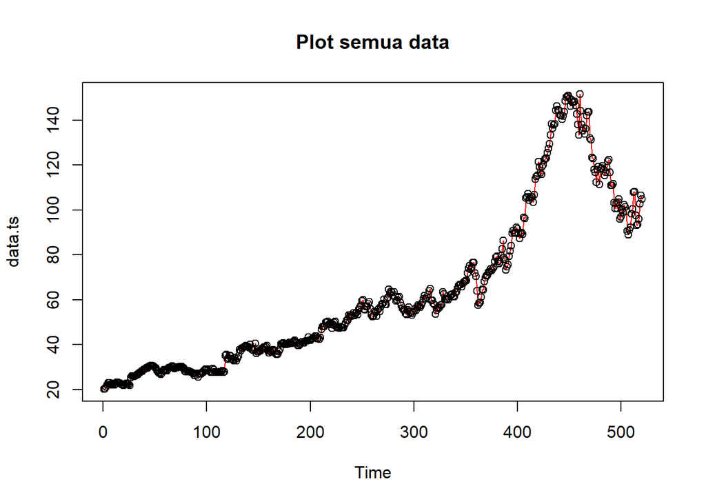

```r
#eksplorasi keseluruhan data
plot(data.ts, col="red",main="Plot semua data")
points(data.ts)
```

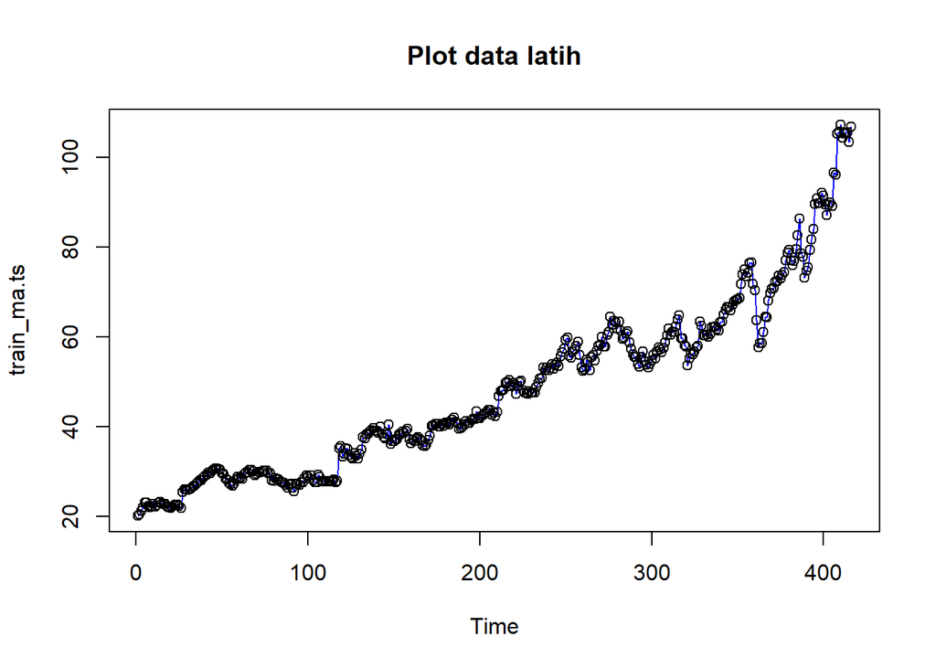

```r
#eksplorasi data latih
plot(train_ma.ts, col="blue",main="Plot data latih")
points(train_ma.ts)
```

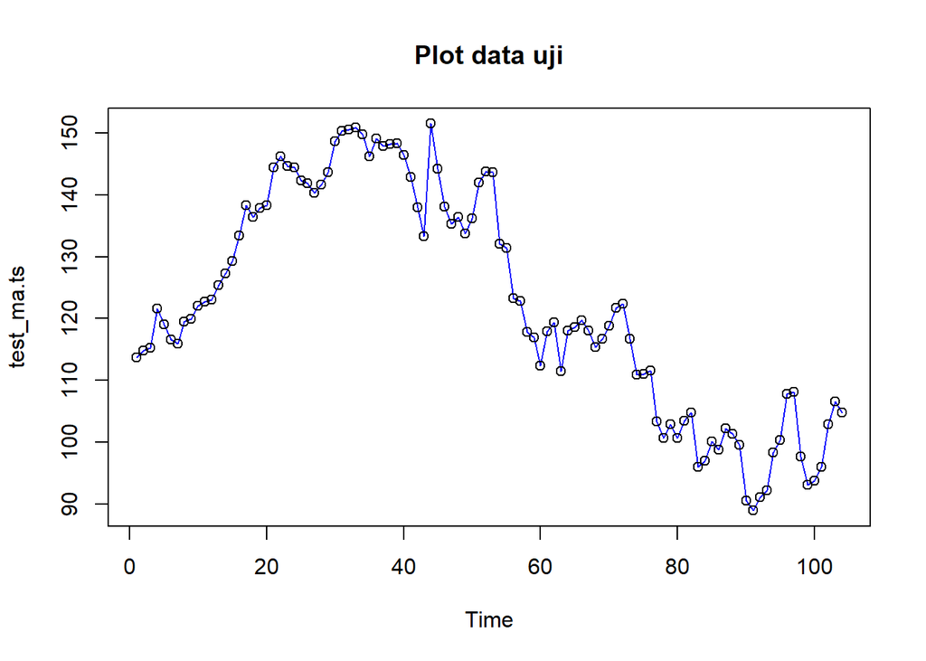

```r
#eksplorasi data uji
plot(test_ma.ts, col="blue",main="Plot data uji")
points(test_ma.ts)
```

Eksplorasi data juga dapat dilakukan menggunakan package `ggplot2` dengan terlebih dahulu memanggil library *package* `ggplot2`.

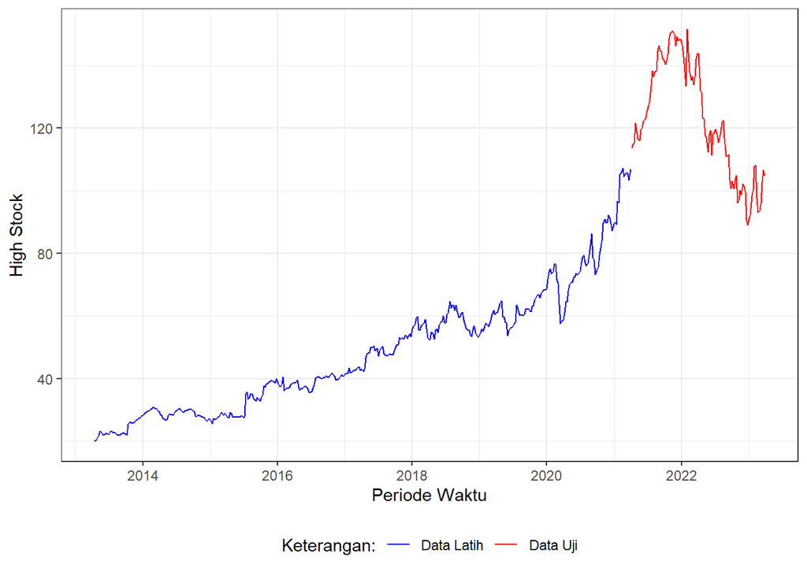

```r
#Eksplorasi dengan GGPLOT

library(ggplot2)
ggplot() +
  geom_line(data = training, aes(x = tanggal, y = stock, col = "Data Latih")) +
  geom_line(data = testing, aes(x = tanggal, y = stock, col = "Data Uji")) +
  labs(x = "Periode Waktu", y = "High Stock", color = "Legend") +
  scale_colour_manual(name="Keterangan:", breaks = c("Data Latih", "Data Uji"),
                      values = c("blue", "red")) +
  theme_bw() + theme(legend.position = "bottom",
                     plot.caption = element_text(hjust=0.5, size=12))
```

### Single Moving Average (SMA)

Ide dasar dari Single Moving Average (SMA) adalah data suatu periode dipengaruhi oleh data periode sebelumnya. Metode pemulusan ini cocok digunakan untuk pola data stasioner atau konstan. Prinsip dasar metode pemulusan ini adalah data pemulusan pada periode ke-t merupakan rata rata dari m buah data pada periode ke-t hingga periode ke (t-m+1). Data pemulusan pada periode ke-t selanjutnya digunakan sebagai nilai peramalan pada periode ke t+1

Pemulusan menggunakan metode SMA dilakukan dengan fungsi `SMA()`. Dalam hal ini akan dilakukan pemulusan dengan parameter `m=4`.

```r
data.sma <- SMA(train_ma.ts, n=4)
data.sma
```

```
## Time Series:
## Start = 1
## End = 416
## Frequency = 1
##   [1]       NA       NA       NA  20.9525  21.6800  22.3225  22.6075  22.6025
##   [9]  22.4225  22.3600  22.3125  22.4100  22.6100  22.7175  22.8950  22.9675
##  [17]  22.8850  22.6375  22.4175  22.2150  22.0525  22.1125  22.2875  22.4550
##  [25]  22.5175  22.3675  23.0525  23.9225  24.8450  25.8375  25.9900  26.0400
##  [33]  26.2075  26.4425  26.7725  27.1025  27.4300  27.7475  28.0900  28.4600
##  [41]  28.7575  29.1675  29.3825  29.6575  29.9375  30.2025  30.4875  30.5700
##  [49]  30.5650  30.2900  29.9675  29.4525  28.9200  28.3575  27.7825  27.3775
##  [57]  27.1275  27.3400  27.7800  28.2125  28.5625  28.5850  28.7350  29.0325
##  [65]  29.3275  29.8250  30.0675  30.1550  30.0075  29.7925  29.6525  29.5825
##  [73]  29.7650  29.9425  30.0375  30.1400  30.0475  29.9075  29.3500  28.7700
##  [81]  28.4925  28.1775  28.2000  28.1725  27.9700  27.7400  27.4500  27.0775
```

[output cut: 41 more lines]

Data pemulusan pada periode ke-t selanjutnya digunakan sebagai nilai peramalan pada periode ke t+1 sehingga hasil peramalan 1 periode kedepan adalah sebagai berikut.

```r
data.ramal <- c(NA,data.sma)
data.ramal #forecast 1 periode ke depan
```

```
##   [1]       NA       NA       NA       NA  20.9525  21.6800  22.3225  22.6075
##   [9]  22.6025  22.4225  22.3600  22.3125  22.4100  22.6100  22.7175  22.8950
##  [17]  22.9675  22.8850  22.6375  22.4175  22.2150  22.0525  22.1125  22.2875
##  [25]  22.4550  22.5175  22.3675  23.0525  23.9225  24.8450  25.8375  25.9900
##  [33]  26.0400  26.2075  26.4425  26.7725  27.1025  27.4300  27.7475  28.0900
##  [41]  28.4600  28.7575  29.1675  29.3825  29.6575  29.9375  30.2025  30.4875
##  [49]  30.5700  30.5650  30.2900  29.9675  29.4525  28.9200  28.3575  27.7825
##  [57]  27.3775  27.1275  27.3400  27.7800  28.2125  28.5625  28.5850  28.7350
##  [65]  29.0325  29.3275  29.8250  30.0675  30.1550  30.0075  29.7925  29.6525
##  [73]  29.5825  29.7650  29.9425  30.0375  30.1400  30.0475  29.9075  29.3500
##  [81]  28.7700  28.4925  28.1775  28.2000  28.1725  27.9700  27.7400  27.4500
##  [89]  27.0775  26.9600  26.9000  26.7575  26.5750  26.6025  26.5925  26.7450
##  [97]  27.2675  27.3625  27.6900  28.2275  28.5125  28.6875  28.8425  28.5825
## [105]  28.2850  28.1125  28.1500  28.3150  28.3775  28.3800  28.0475  27.8000
## [113]  27.8275  27.8450  27.8425  27.9650  27.8675  27.9225  29.7350  31.5825
```

[output cut: 38 more lines]

Selanjutnya akan dilakukan peramalan sejumlah data uji yaitu 104 periode. Pada metode SMA, hasil peramalan 104 periode ke depan akan bernilai sama dengan hasil peramalan 1 periode kedepan. Dalam hal ini akan dilakukan pengguabungan data aktual train, data hasil pemulusan dan data hasil ramalan 104 periode kedepan.

```r
data.gab <- cbind(aktual=c(train_ma.ts,rep(NA,104)),pemulusan=c(data.sma,rep(NA,104)),ramalan=c(data.ramal,rep(data.ramal[length(data.ramal)],103)))
data.gab #forecast 104 periode ke depan
```

```
##        aktual pemulusan  ramalan
##   [1,]  20.11        NA       NA
##   [2,]  20.47        NA       NA
##   [3,]  21.19        NA       NA
##   [4,]  22.04   20.9525       NA
##   [5,]  23.02   21.6800  20.9525
##   [6,]  23.04   22.3225  21.6800
##   [7,]  22.33   22.6075  22.3225
##   [8,]  22.02   22.6025  22.6075
##   [9,]  22.30   22.4225  22.6025
##  [10,]  22.79   22.3600  22.4225
##  [11,]  22.14   22.3125  22.3600
##  [12,]  22.41   22.4100  22.3125
##  [13,]  23.10   22.6100  22.4100
##  [14,]  23.22   22.7175  22.6100
```

[output cut: 506 more lines]

Adapun plot data deret waktu dari hasil peramalan yang dilakukan adalah sebagai berikut.

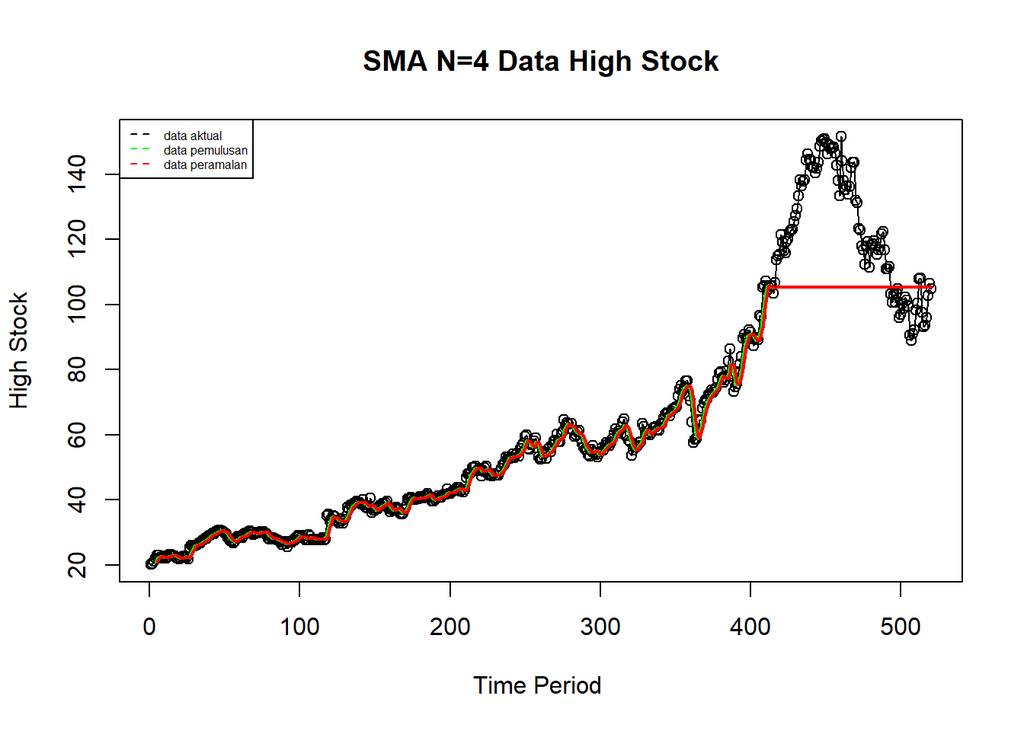

```r
ts.plot(data.ts, xlab="Time Period ", ylab="High Stock", main= "SMA N=4 Data High Stock")
points(data.ts)
lines(data.gab[,2],col="green",lwd=2)
lines(data.gab[,3],col="red",lwd=2)
legend("topleft",c("data aktual","data pemulusan","data peramalan"), lty=8, col=c("black","green","red"), cex=0.5)
```

Selanjutnya perhitungan akurasi dilakukan dengan ukuran akurasi *Sum Squares Error* (SSE), *Mean Square Error* (MSE) dan *Mean Absolute Percentage Error* (MAPE). Perhitungan akurasi dilakukan baik pada data latih maupun pada data uji.

```r
#Menghitung nilai keakuratan data latih
error_train_ma.sma = train_ma.ts - data.ramal[1:length(train_ma.ts)]
SSE_train_ma.sma = sum(error_train_ma.sma[5:length(train_ma.ts)]^2)
MSE_train_ma.sma = mean(error_train_ma.sma[5:length(train_ma.ts)]^2)
MAPE_train_ma.sma = mean(abs((error_train_ma.sma[5:length(train_ma.ts)]/train_ma.ts[5:length(train_ma.ts)])*100))

akurasi_train_ma.sma <- matrix(c(SSE_train_ma.sma, MSE_train_ma.sma, MAPE_train_ma.sma))
row.names(akurasi_train_ma.sma)<- c("SSE", "MSE", "MAPE")
colnames(akurasi_train_ma.sma) <- c("Akurasi m = 4")
akurasi_train_ma.sma
```

```
##      Akurasi m = 4
## SSE    2323.920831
## MSE       5.640585
## MAPE      3.042070
```

```r
#Menghitung nilai keakuratan data uji
error_test_ma.sma = test_ma.ts-data.gab[417:520,3]
SSE_test_ma.sma = sum(error_test_ma.sma^2)
MSE_test_ma.sma = mean(error_test_ma.sma^2)
MAPE_test_ma.sma = mean(abs((error_test_ma.sma/test_ma.ts*100)))

akurasi_test_ma.sma <- matrix(c(SSE_test_ma.sma, MSE_test_ma.sma, MAPE_test_ma.sma))
row.names(akurasi_test_ma.sma)<- c("SSE", "MSE", "MAPE")
colnames(akurasi_test_ma.sma) <- c("Akurasi m = 4")
akurasi_test_ma.sma
```

```
##      Akurasi m = 4
## SSE    64668.35100
## MSE      621.81107
## MAPE      15.55957
```

### Double Moving Average (DMA)

Metode pemulusan Double Moving Average (DMA) pada dasarnya mirip dengan Single Moving Average (SMA). Namun, metode ini lebih cocok digunakan untuk pola data trend. Proses pemulusan dengan rata-rata dalam metode ini dilakukan sebanyak 2 kali.

```r
dma <- SMA(data.sma, n = 4)
At <- 2*data.sma - dma
Bt <- 2/(4-1)*(data.sma - dma)
data.dma<- At+Bt
data.ramal2<- c(NA, data.dma)

t = 1:104
f = c()

for (i in t) {
  f[i] = At[length(At)] + Bt[length(Bt)]*(i)
}

data.gab2 <- cbind(aktual = c(train_ma.ts,rep(NA,104)), pemulusan1 = c(data.sma,rep(NA,104)),pemulusan2 = c(data.dma, rep(NA,104)),At = c(At, rep(NA,104)), Bt = c(Bt,rep(NA,104)),ramalan = c(data.ramal2, f[-1]))
data.gab2
```

```
##        aktual pemulusan1 pemulusan2        At           Bt   ramalan
##   [1,]  20.11         NA         NA        NA           NA        NA
##   [2,]  20.47         NA         NA        NA           NA        NA
##   [3,]  21.19         NA         NA        NA           NA        NA
##   [4,]  22.04    20.9525         NA        NA           NA        NA
##   [5,]  23.02    21.6800         NA        NA           NA        NA
##   [6,]  23.04    22.3225         NA        NA           NA        NA
##   [7,]  22.33    22.6075   23.80229  23.32437  0.477916667        NA
##   [8,]  22.02    22.6025   23.10146  22.90188  0.199583333  23.80229
##   [9,]  22.30    22.4225   22.31208  22.35625 -0.044166667  23.10146
##  [10,]  22.79    22.3600   22.12979  22.22188 -0.092083333  22.31208
##  [11,]  22.14    22.3125   22.12604  22.20063 -0.074583333  22.12979
##  [12,]  22.41    22.4100   22.46625  22.44375  0.022500000  22.12604
##  [13,]  23.10    22.6100   22.92146  22.79688  0.124583333  22.46625
##  [14,]  23.22    22.7175   23.05917  22.92250  0.136666667  22.92146
```

[output cut: 506 more lines]

Hasil pemulusan menggunakan metode DMA divisualisasikan sebagai berikut

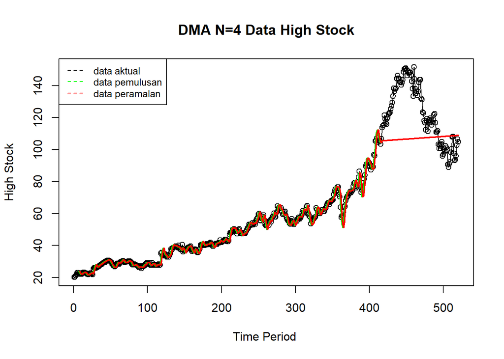

```r
ts.plot(data.ts, xlab="Time Period ", ylab="High Stock", main= "DMA N=4 Data High Stock")
points(data.ts)
lines(data.gab2[,3],col="green",lwd=2)
lines(data.gab2[,6],col="red",lwd=2)
legend("topleft",c("data aktual","data pemulusan","data peramalan"), lty=8, col=c("black","green","red"), cex=0.8)
```

Selanjutnya perhitungan akurasi dilakukan baik pada data latih maupun data uji. Perhitungan akurasi dilakukan dengan ukuran akurasi SSE, MSE dan MAPE.

```r
#Menghitung nilai keakuratan data latih
error_train_ma.dma = train_ma.ts-data.ramal2[1:length(train_ma.ts)]
SSE_train_ma.dma = sum(error_train_ma.dma[8:length(train_ma.ts)]^2)
MSE_train_ma.dma = mean(error_train_ma.dma[8:length(train_ma.ts)]^2)
MAPE_train_ma.dma = mean(abs((error_train_ma.dma[8:length(train_ma.ts)]/train_ma.ts[8:length(train_ma.ts)])*100))

akurasi_train_ma.dma <- matrix(c(SSE_train_ma.dma, MSE_train_ma.dma, MAPE_train_ma.dma))
row.names(akurasi_train_ma.dma)<- c("SSE", "MSE", "MAPE")
colnames(akurasi_train_ma.dma) <- c("Akurasi m = 4")
akurasi_train_ma.dma
```

```
##      Akurasi m = 4
## SSE    2214.402400
## MSE       5.414187
## MAPE      3.031726
```

Perhitungan akurasi pada data latih menggunakan nilai MAPE menghasilkan nilai MAPE yang kurang dari 10% sehingga dikategorikan sangat baik. Selanjutnya, perhitungan nilai akurasi dilakukan pada data uji.

```r
#Menghitung nilai keakuratan data uji
error_test_ma.dma = test_ma.ts-data.gab2[417:520,6]
SSE_test_ma.dma = sum(error_test_ma.dma^2)
MSE_test_ma.dma = mean(error_test_ma.dma^2)
MAPE_test_ma.dma = mean(abs((error_test_ma.dma/test_ma.ts*100)))

akurasi_test_ma.dma <- matrix(c(SSE_test_ma.dma, MSE_test_ma.dma, MAPE_test_ma.dma))
row.names(akurasi_test_ma.dma)<- c("SSE", "MSE", "MAPE")
colnames(akurasi_test_ma.dma) <- c("Akurasi m = 4")
akurasi_test_ma.dma
```

```
##      Akurasi m = 4
## SSE    61334.97014
## MSE      589.75933
## MAPE      15.51519
```

Pada data latih maupun data uji, metode DMA lebih baik dibandingkan dengan metode SMA. Oleh karena itu, dapat terbukti bahwa data trend lebih cocok menggunakan metode DMA.

## Single Exponential Smoothing & Double Exponential Smoothing

Metode *Exponential Smoothing* adalah metode pemulusan dengan melakukan pembobotan menurun secara eksponensial. Nilai yang lebih baru diberi bobot yang lebih besar dari nilai terdahulu. Terdapat satu atau lebih parameter pemulusan yang ditentukan secara eksplisit, dan hasil pemilihan parameter tersebut akan menentukan bobot yang akan diberikan pada nilai pengamatan. Ada dua macam model, yaitu model tunggal dan ganda.

### Pembagian Data

Pembagian data latih dan data uji dilakukan dengan perbandingan 80% data latih dan 20% data uji.

```r
#membagi training dan testing
training <- data[1:416,]
testing <- data[417:520,]
train_es.ts <- ts(training$stock)
test_es.ts <- ts(testing$stock)
```

### Eksplorasi

Eksplorasi dilakukan dengan membuat plot data deret waktu untuk keseluruhan data, data latih, dan data uji.

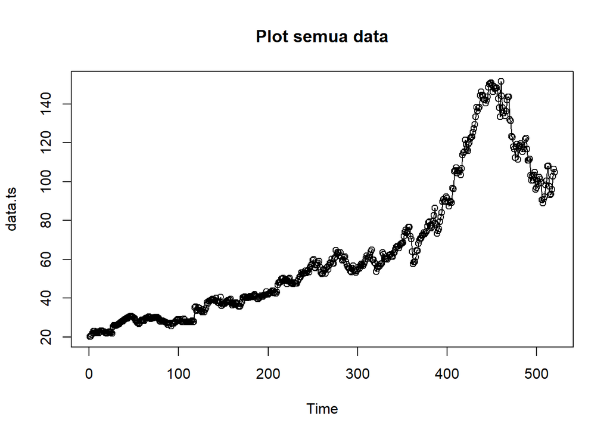

```r
#eksplorasi data
plot(data.ts, col="black",main="Plot semua data")
points(data.ts)
```

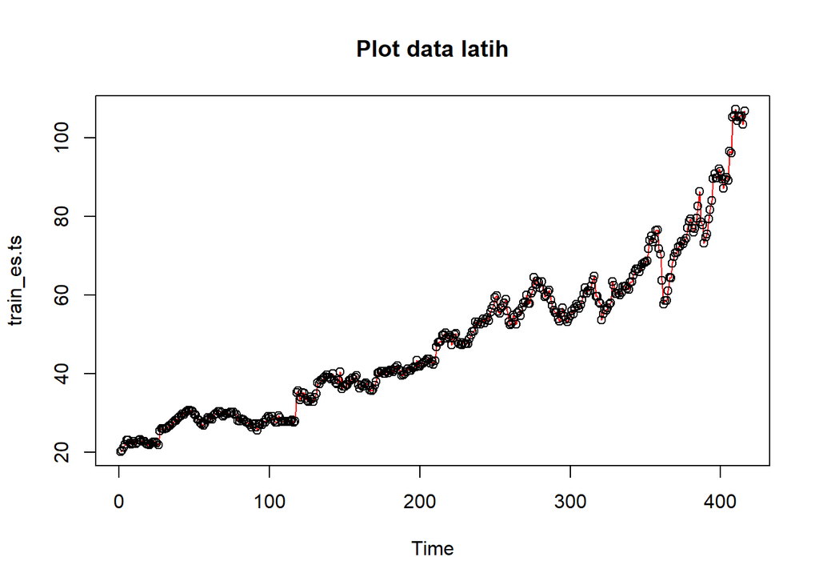

```r
plot(train_es.ts, col="red",main="Plot data latih")
points(train_es.ts)
```

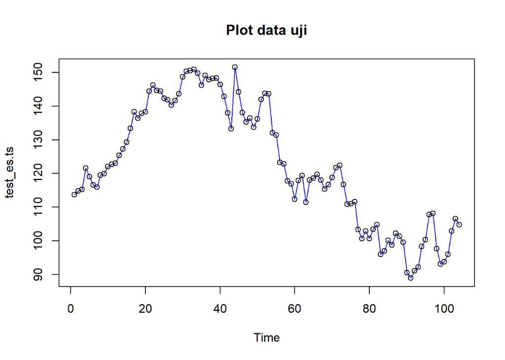

```r
plot(test_es.ts, col="blue",main="Plot data uji")
points(test_es.ts)
```

Eksplorasi data juga dapat dilakukan menggunakan package `ggplot2` .

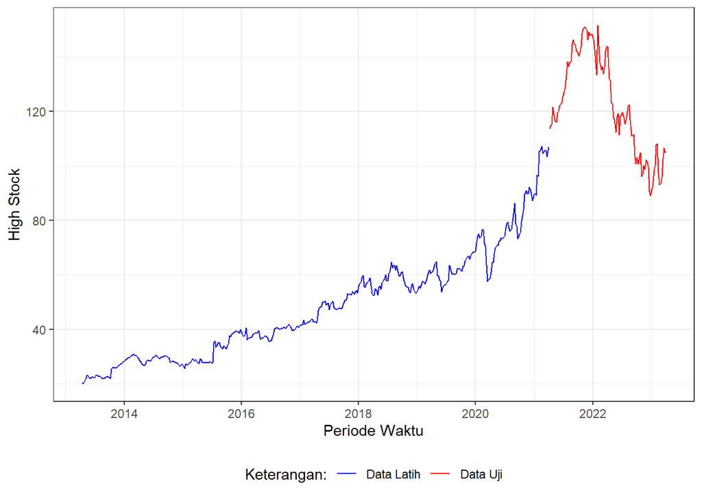

```r
#Eksplorasi dengan GGPLOT
library(ggplot2)
ggplot() +
  geom_line(data = training, aes(x = tanggal, y = stock, col = "Data Latih")) +
  geom_line(data = testing, aes(x = tanggal, y = stock, col = "Data Uji")) +
  labs(x = "Periode Waktu", y = "High Stock", color = "Legend") +
  scale_colour_manual(name="Keterangan:", breaks = c("Data Latih", "Data Uji"),
                      values = c("blue", "red")) +
  theme_bw() + theme(legend.position = "bottom",
                     plot.caption = element_text(hjust=0.5, size=12))
```

### SES

Single Exponential Smoothing merupakan metode pemulusan yang tepat digunakan untuk data dengan pola stasioner atau konstan.

Nilai pemulusan pada periode ke-t didapat dari persamaan:

$$\tilde{y}_T=\lambda y_t+(1-\lambda)\tilde{y}_{T-1}$$

Nilai parameter $\lambda$ adalah nilai antara 0 dan 1.

Nilai pemulusan periode ke-t bertindak sebagai nilai ramalan pada periode ke-$(T+\tau)$.

$$\tilde{y}_{T+\tau}(T)=\tilde{y}_T$$

Pemulusan dengan metode SES dapat dilakukan dengan dua fungsi dari *packages* berbeda, yaitu (1) fungsi `ses()` dari *packages* `forecast` dan (2) fungsi `HoltWinters` dari *packages* `stats` .

```r
#Cara 1 (fungsi ses)
ses.1 <- ses(train_es.ts, h = 104, beta = 0.2)
plot(ses.1)
ses.1
```

```
##     Point Forecast     Lo 80    Hi 80     Lo 95    Hi 95
## 417       106.7897 104.75154 108.8278 103.67262 109.9067
## 418       106.7897 103.90746 109.6719 102.38172 111.1976
## 419       106.7897 103.25976 110.3196 101.39115 112.1882
## 420       106.7897 102.71372 110.8656 100.55605 113.0233
## 421       106.7897 102.23264 111.3467  99.82030 113.7590
## 422       106.7897 101.79771 111.7816  99.15514 114.4242
## 423       106.7897 101.39776 112.1816  98.54345 115.0359
## 424       106.7897 101.02548 112.5538  97.97411 115.6052
## 425       106.7897 100.67583 112.9035  97.43937 116.1399
## 426       106.7897 100.34513 113.2342  96.93360 116.6457
## 427       106.7897 100.03059 113.5487  96.45255 117.1268
## 428       106.7897  99.73004 113.8493  95.99291 117.5864
## 429       106.7897  99.44178 114.1375  95.55205 118.0273
## 430       106.7897  99.16441 114.4149  95.12785 118.4515
```

[output cut: 90 more lines]

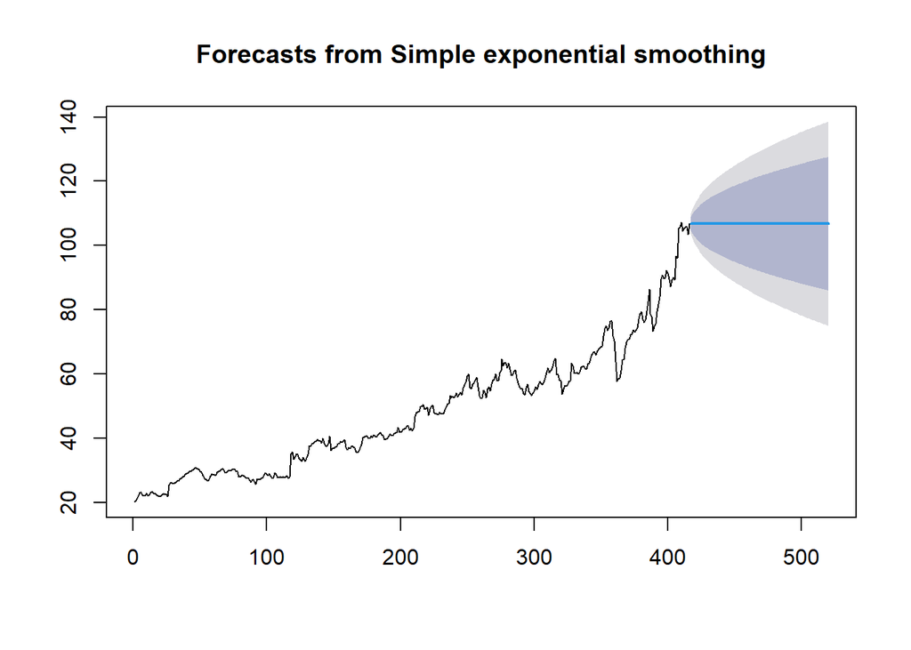

```r
ses.2<- ses(train_es.ts, h = 104, beta = 0.7)
plot(ses.2)
```

```r
ses.2
```

```
##     Point Forecast     Lo 80    Hi 80     Lo 95    Hi 95
## 417       106.7897 104.75154 108.8278 103.67262 109.9067
## 418       106.7897 103.90746 109.6719 102.38172 111.1976
## 419       106.7897 103.25976 110.3196 101.39115 112.1882
## 420       106.7897 102.71372 110.8656 100.55605 113.0233
## 421       106.7897 102.23264 111.3467  99.82030 113.7590
## 422       106.7897 101.79771 111.7816  99.15514 114.4242
## 423       106.7897 101.39776 112.1816  98.54345 115.0359
## 424       106.7897 101.02548 112.5538  97.97411 115.6052
## 425       106.7897 100.67583 112.9035  97.43937 116.1399
## 426       106.7897 100.34513 113.2342  96.93360 116.6457
## 427       106.7897 100.03059 113.5487  96.45255 117.1268
## 428       106.7897  99.73004 113.8493  95.99291 117.5864
## 429       106.7897  99.44178 114.1375  95.55205 118.0273
## 430       106.7897  99.16441 114.4149  95.12785 118.4515
```

[output cut: 90 more lines]

Untuk mendapatkan gambar hasil pemulusan pada data latih dengan fungsi `ses()` , perlu digunakan fungsi `autoplot()` dan `autolayer()` dari *library packages* `ggplot2` .

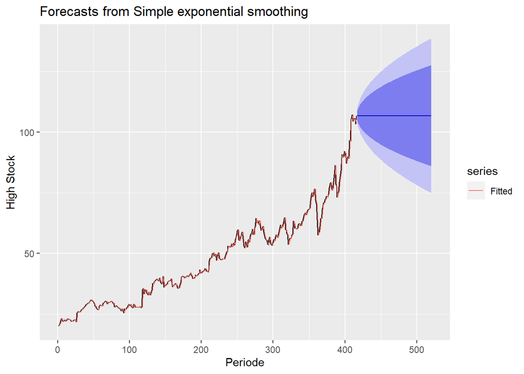

```r
autoplot(ses.1) +
  autolayer(fitted(ses.1), series="Fitted") +
  ylab("High Stock") + xlab("Periode")
```

Pada fungsi `ses()` , terdapat beberapa argumen yang umum digunakan, yaitu nilia `y` , `gamma` , `beta` , `alpha` , dan `h` .

Nilai `y` adalah nilai data deret waktu, `gamma` adalah parameter pemulusan untuk komponen musiman, `beta` adalah parameter pemulusan untuk tren, dan `alpha` adalah parameter pemulusan untuk stasioner, serta `h` adalah banyaknya periode yang akan diramalkan.

```r
#Cara 2 (fungsi Holtwinter)
ses1<- HoltWinters(train_es.ts, gamma = FALSE, beta = FALSE, alpha = 0.2)
plot(ses1)

#ramalan
ramalan1<- forecast(ses1, h=104)
ramalan1
```

```
##     Point Forecast     Lo 80    Hi 80    Lo 95    Hi 95
## 417       103.5885 100.21334 106.9637 98.42663 108.7504
## 418       103.5885 100.14650 107.0305 98.32440 108.8526
## 419       103.5885 100.08093 107.0961 98.22412 108.9529
## 420       103.5885 100.01656 107.1605 98.12569 109.0513
## 421       103.5885  99.95334 107.2237 98.02899 109.1480
## 422       103.5885  99.89119 107.2858 97.93395 109.2431
## 423       103.5885  99.83008 107.3470 97.84048 109.3366
## 424       103.5885  99.76994 107.4071 97.74851 109.4285
## 425       103.5885  99.71073 107.4663 97.65796 109.5191
## 426       103.5885  99.65242 107.5246 97.56877 109.6083
## 427       103.5885  99.59495 107.5821 97.48089 109.6961
## 428       103.5885  99.53830 107.6387 97.39425 109.7828
## 429       103.5885  99.48244 107.6946 97.30881 109.8682
## 430       103.5885  99.42732 107.7497 97.22451 109.9525
```

[output cut: 90 more lines]

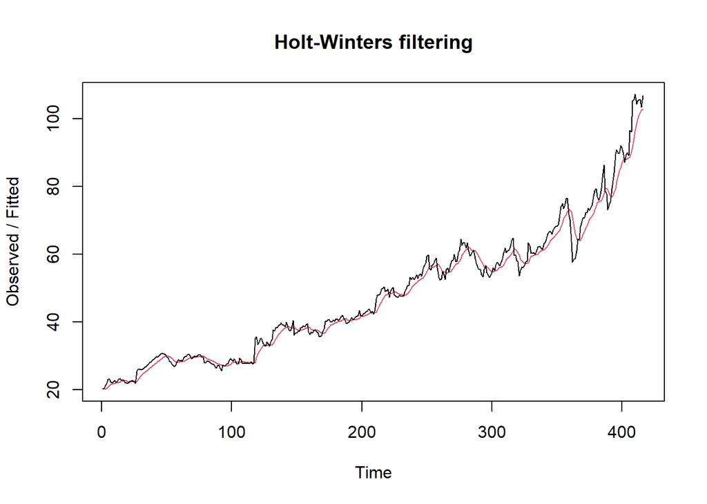

```r
ses2<- HoltWinters(train_es.ts, gamma = FALSE, beta = FALSE, alpha = 0.2)
plot(ses2)
```

```r
#ramalan
ramalan2<- forecast(ses2, h=104)
ramalan2
```

```
##     Point Forecast     Lo 80    Hi 80    Lo 95    Hi 95
## 417       103.5885 100.21334 106.9637 98.42663 108.7504
## 418       103.5885 100.14650 107.0305 98.32440 108.8526
## 419       103.5885 100.08093 107.0961 98.22412 108.9529
## 420       103.5885 100.01656 107.1605 98.12569 109.0513
## 421       103.5885  99.95334 107.2237 98.02899 109.1480
## 422       103.5885  99.89119 107.2858 97.93395 109.2431
## 423       103.5885  99.83008 107.3470 97.84048 109.3366
## 424       103.5885  99.76994 107.4071 97.74851 109.4285
## 425       103.5885  99.71073 107.4663 97.65796 109.5191
## 426       103.5885  99.65242 107.5246 97.56877 109.6083
## 427       103.5885  99.59495 107.5821 97.48089 109.6961
## 428       103.5885  99.53830 107.6387 97.39425 109.7828
## 429       103.5885  99.48244 107.6946 97.30881 109.8682
## 430       103.5885  99.42732 107.7497 97.22451 109.9525
```

[output cut: 90 more lines]

Fungsi `HoltWinters` memiliki argumen yang sama dengan fungsi `ses()` . Argumen-argumen kedua fungsi dapat dilihat lebih lanjut dengan `?ses()` atau `?HoltWinters` .

Nilai parameter $\alpha$ dari kedua fungsi dapat dioptimalkan menyesuaikan dari *error*-nya paling minimumnya. Caranya adalah dengan membuat parameter $\alpha =$ `NULL` .

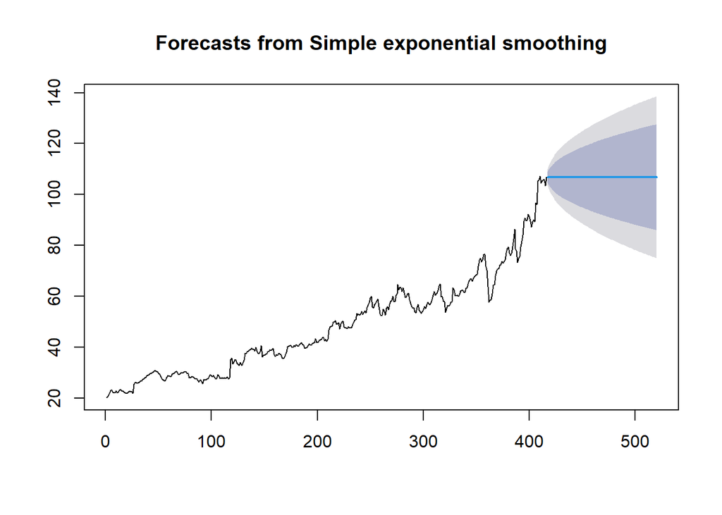

```r
#SES
ses.opt <- ses(train_es.ts, h = 104, alpha = NULL)
plot(ses.opt)
```

```r
ses.opt
```

```
##     Point Forecast     Lo 80    Hi 80     Lo 95    Hi 95
## 417       106.7897 104.75154 108.8278 103.67262 109.9067
## 418       106.7897 103.90746 109.6719 102.38172 111.1976
## 419       106.7897 103.25976 110.3196 101.39115 112.1882
## 420       106.7897 102.71372 110.8656 100.55605 113.0233
## 421       106.7897 102.23264 111.3467  99.82030 113.7590
## 422       106.7897 101.79771 111.7816  99.15514 114.4242
## 423       106.7897 101.39776 112.1816  98.54345 115.0359
## 424       106.7897 101.02548 112.5538  97.97411 115.6052
## 425       106.7897 100.67583 112.9035  97.43937 116.1399
## 426       106.7897 100.34513 113.2342  96.93360 116.6457
## 427       106.7897 100.03059 113.5487  96.45255 117.1268
## 428       106.7897  99.73004 113.8493  95.99291 117.5864
## 429       106.7897  99.44178 114.1375  95.55205 118.0273
## 430       106.7897  99.16441 114.4149  95.12785 118.4515
```

[output cut: 90 more lines]

```r
#Lamda Optimum Holt Winter
sesopt<- HoltWinters(train_es.ts, gamma = FALSE, beta = FALSE,alpha = NULL)
sesopt
```

```
## Holt-Winters exponential smoothing without trend and without seasonal component.
##
## Call:
## HoltWinters(x = train_es.ts, alpha = NULL, beta = FALSE, gamma = FALSE)
##
## Smoothing parameters:
##  alpha: 0.9999352
##  beta : FALSE
##  gamma: FALSE
##
## Coefficients:
##       [,1]
## a 106.7898
```

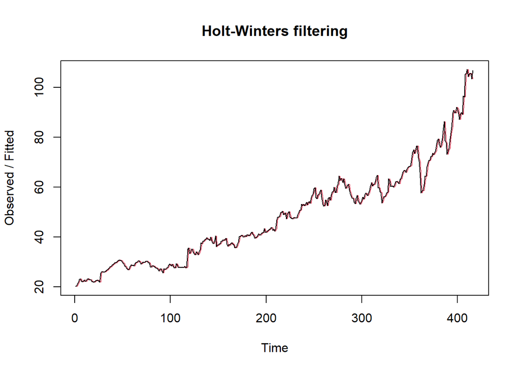

```r
plot(sesopt)
```

```r
#ramalan
ramalanopt<- forecast(sesopt, h=104)
ramalanopt
```

```
##     Point Forecast     Lo 80    Hi 80     Lo 95    Hi 95
## 417       106.7898 104.76936 108.8102 103.69982 109.8797
## 418       106.7898 103.93257 109.6470 102.42006 111.1595
## 419       106.7898 103.29047 110.2891 101.43804 112.1415
## 420       106.7898 102.74914 110.8304 100.61016 112.9694
## 421       106.7898 102.27222 111.3073  99.88078 113.6988
## 422       106.7898 101.84106 111.7385  99.22136 114.3582
## 423       106.7898 101.44456 112.1350  98.61497 114.9646
## 424       106.7898 101.07550 112.5041  98.05055 115.5290
## 425       106.7898 100.72888 112.8507  97.52043 116.0591
## 426       106.7898 100.40103 113.1785  97.01904 116.5605
## 427       106.7898 100.08921 113.4903  96.54214 117.0374
## 428       106.7898  99.79127 113.7883  96.08648 117.4931
## 429       106.7898  99.50550 114.0741  95.64943 117.9301
## 430       106.7898  99.23053 114.3490  95.22890 118.3507
```

[output cut: 90 more lines]

Setelah dilakukan peramalan, akan dilakukan perhitungan keakuratan hasil peramalan. Perhitungan akurasi ini dilakukan baik pada data latih dan data uji.

#### Akurasi Data Latih

Perhitungan akurasi data dapat dilakukan dengan cara langsung maupun manual. Secara langsung, nilai akurasi dapat diambil dari objek yang tersimpan pada hasil SES, yaitu *sum of squared errors* (SSE). Nilai akurasi lain dapat dihitung pula dari nilai SSE tersebut.

```r
#Keakuratan Metode
#Pada data training
SSE1<-ses1$SSE
MSE1<-ses1$SSE/length(train_es.ts)
RMSE1<-sqrt(MSE1)

akurasi1 <- matrix(c(SSE1,MSE1,RMSE1))
row.names(akurasi1)<- c("SSE", "MSE", "RMSE")
colnames(akurasi1) <- c("Akurasi lamda=0.2")
akurasi1
```

```
##      Akurasi lamda=0.2
## SSE        3291.384059
## MSE           7.911981
## RMSE          2.812824
```

```r
SSE2<-ses2$SSE
MSE2<-ses2$SSE/length(train_es.ts)
RMSE2<-sqrt(MSE2)

akurasi2 <- matrix(c(SSE2,MSE2,RMSE2))
row.names(akurasi2)<- c("SSE", "MSE", "RMSE")
colnames(akurasi2) <- c("Akurasi lamda=0.7")
akurasi2
```

```
##      Akurasi lamda=0.7
## SSE        3291.384059
## MSE           7.911981
## RMSE          2.812824
```

```r
#Cara Manual
fitted1<-ramalan1$fitted
sisaan1<-ramalan1$residuals
head(sisaan1)
```

```
## Time Series:
## Start = 1
## End = 6
## Frequency = 1
## [1]       NA 0.360000 1.008000 1.656400 2.305120 1.864096
```

```r
resid1<-training$stock-ramalan1$fitted
head(resid1)
```

```
## Time Series:
## Start = 1
## End = 6
## Frequency = 1
## [1]       NA 0.360000 1.008000 1.656400 2.305120 1.864096
```

```r
#Cara Manual
SSE.1=sum(sisaan1[2:length(train_es.ts)]^2)
SSE.1
```

```
## [1] 3291.384
```

```r
MSE.1 = SSE.1/length(train_es.ts)
MSE.1
```

```
## [1] 7.911981
```

```r
MAPE.1 = sum(abs(sisaan1[2:length(train_es.ts)]/train_es.ts[2:length(train_es.ts)])*
               100)/length(train_es.ts)
MAPE.1
```

```
## [1] 3.794075
```

```r
akurasi.1 <- matrix(c(SSE.1,MSE.1,MAPE.1))
row.names(akurasi.1)<- c("SSE", "MSE", "MAPE")
colnames(akurasi.1) <- c("Akurasi lamda=0.2")
akurasi.1
```

```
##      Akurasi lamda=0.2
## SSE        3291.384059
## MSE           7.911981
## MAPE          3.794075
```

```r
fitted2<-ramalan2$fitted
sisaan2<-ramalan2$residuals
head(sisaan2)
```

```
## Time Series:
## Start = 1
## End = 6
## Frequency = 1
## [1]       NA 0.360000 1.008000 1.656400 2.305120 1.864096
```

```r
resid2<-training$stock-ramalan2$fitted
head(resid2)
```

```
## Time Series:
## Start = 1
## End = 6
## Frequency = 1
## [1]       NA 0.360000 1.008000 1.656400 2.305120 1.864096
```

```r
SSE.2=sum(sisaan2[2:length(train_es.ts)]^2)
SSE.2
```

```
## [1] 3291.384
```

```r
MSE.2 = SSE.2/length(train_es.ts)
MSE.2
```

```
## [1] 7.911981
```

```r
MAPE.2 = sum(abs(sisaan2[2:length(train_es.ts)]/train_es.ts[2:length(train_es.ts)])*
               100)/length(train_es.ts)
MAPE.2
```

```
## [1] 3.794075
```

```r
akurasi.2 <- matrix(c(SSE.2,MSE.2,MAPE.2))
row.names(akurasi.2)<- c("SSE", "MSE", "MAPE")
colnames(akurasi.2) <- c("Akurasi lamda=0.7")
akurasi.2
```

```
##      Akurasi lamda=0.7
## SSE        3291.384059
## MSE           7.911981
## MAPE          3.794075
```

#### Akurasi Data Uji

Akurasi data uji dapat dihitung dengan cara yang hampir sama dengan perhitungan akurasi data latih.

```r
selisih1<-ramalan1$mean-testing$stock
SSEtesting1<-sum(selisih1^2)
MSEtesting1<-SSEtesting1/length(testing)

selisih2<-ramalan2$mean-testing$stock
SSEtesting2<-sum(selisih2^2)
MSEtesting2<-SSEtesting2/length(testing)

selisihopt<-ramalanopt$mean-testing$stock
SSEtestingopt<-sum(selisihopt^2)
MSEtestingopt<-SSEtestingopt/length(testing)

akurasitesting1 <- matrix(c(SSEtesting1,SSEtesting2,SSEtestingopt))
row.names(akurasitesting1)<- c("SSE1", "SSE2", "SSEopt")
akurasitesting1
```

```
##            [,1]
## SSE1   71416.83
## SSE2   71416.83
## SSEopt 59859.00
```

```r
akurasitesting2 <- matrix(c(MSEtesting1,MSEtesting2,MSEtestingopt))
row.names(akurasitesting2)<- c("MSE1", "MSE2", "MSEopt")
akurasitesting2
```

```
##            [,1]
## MSE1   23805.61
## MSE2   23805.61
## MSEopt 19953.00
```

Selain dengan cara di atas, perhitungan nilai akurasi dapat menggunakan fungsi `accuracy()` dari *package* `forecast` . Penggunaannya yaitu dengan menuliskan `accuracy(hasil ramalan, kondisi aktual)` . Contohnya adalah sebagai berikut.

```r
#cara lain
accuracy(ramalanopt,testing$stock)
```

```
##                      ME      RMSE       MAE        MPE     MAPE      MASE
## Training set  0.2088805  1.588433  1.007533  0.3586878  2.00614  1.000015
## Test set     15.7570479 23.990984 19.786745 10.8685842 15.07845 19.639097
##                    ACF1
## Training set 0.08262543
## Test set             NA
```

### DES

Metode pemulusan *Double Exponential Smoothing* (DES) digunakan untuk data yang memiliki pola tren. Metode DES adalah metode semacam SES, hanya saja dilakukan dua kali, yaitu pertama untuk tahapan ‘level’ dan kedua untuk tahapan ‘tren’. Pemulusan menggunakan metode ini akan menghasilkan peramalan tidak konstan untuk periode berikutnya.

Pemulusan dengan metode DES kali ini akan menggunakan fungsi `HoltWinters()` . Jika sebelumnya nilai argumen `beta` dibuat `FALSE` , kali ini argumen tersebut akan diinisialisasi bersamaan dengan nilai `alpha` .

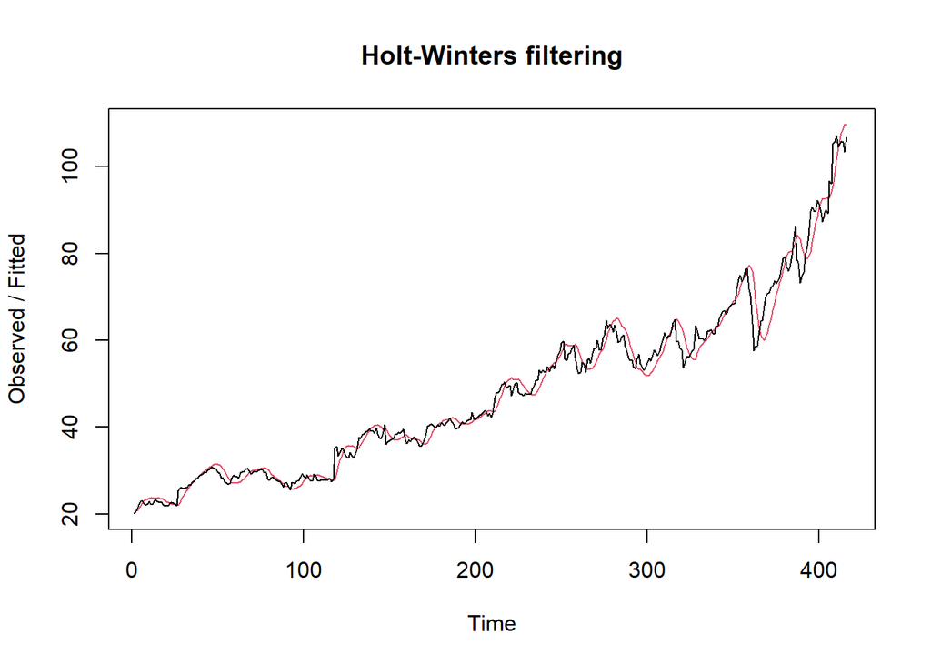

```r
#Lamda=0.2 dan gamma=0.2
des.1<- HoltWinters(train_es.ts, gamma = FALSE, beta = 0.2, alpha = 0.2)
plot(des.1)
```

```r
#ramalan
ramalandes1<- forecast(des.1, h=104)
ramalandes1
```

```
##     Point Forecast    Lo 80    Hi 80     Lo 95    Hi 95
## 417       110.1988 106.5203 113.8772 104.57307 115.8245
## 418       111.3140 107.5311 115.0969 105.52853 117.0995
## 419       112.4292 108.5086 116.3498 106.43314 118.4253
## 420       113.5444 109.4509 117.6379 107.28394 119.8049
## 421       114.6596 110.3573 118.9620 108.07972 121.2396
## 422       115.7748 111.2278 120.3219 108.82078 122.7289
## 423       116.8901 112.0636 121.7166 109.50858 124.2715
## 424       118.0053 112.8660 123.1446 110.14537 125.8652
## 425       119.1205 113.6368 124.6042 110.73384 127.5071
## 426       120.2357 114.3778 126.0936 111.27686 129.1945
## 427       121.3509 115.0911 127.6108 111.77729 130.9245
## 428       122.4661 115.7782 129.1540 112.23786 132.6944
## 429       123.5813 116.4410 130.7217 112.66109 134.5016
## 430       124.6966 117.0808 132.3123 113.04930 136.3438
```

[output cut: 90 more lines]

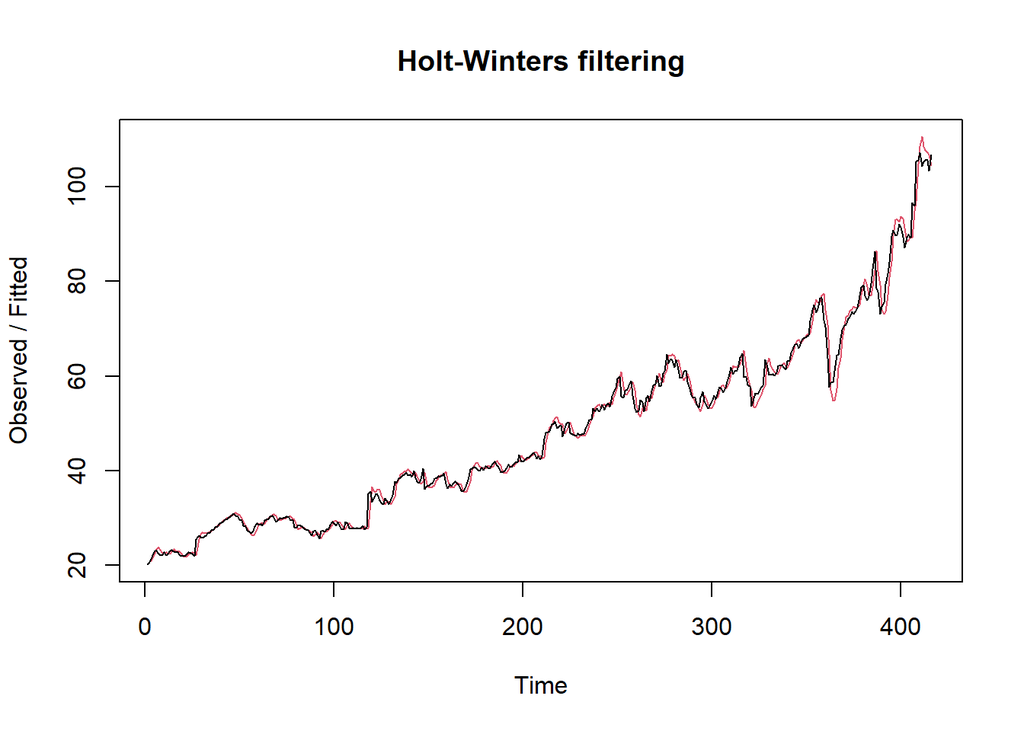

```r
#Lamda=0.6 dan gamma=0.3
des.2<- HoltWinters(train_es.ts, gamma = FALSE, beta = 0.3, alpha = 0.6)
plot(des.2)
```

```r
#ramalan
ramalandes2<- forecast(des.2, h=104)
ramalandes2
```

```
##     Point Forecast        Lo 80    Hi 80        Lo 95    Hi 95
## 417       106.1685  103.7391547 108.5978  102.4531402 109.8838
## 418       106.4204  103.3393979 109.5013  101.7084395 111.1323
## 419       106.6722  102.8081090 110.5363  100.7625778 112.5818
## 420       106.9241  102.1700051 111.6781   99.6533567 114.1948
## 421       107.1759  101.4414496 112.9104   98.4058017 115.9460
## 422       107.4278  100.6334464 114.2221   97.0367420 117.8188
## 423       107.6796   99.7537379 115.6055   95.5580186 119.8013
## 424       107.9315   98.8080443 117.0550   93.9783795 121.8846
## 425       108.1834   97.8007804 118.5659   92.3045768 124.0621
## 426       108.4352   96.7354806 120.1349   90.5420159 126.3284
## 427       108.6871   95.6150602 121.7591   88.6951553 128.6790
## 428       108.9389   94.4419821 123.4359   86.7677618 131.1101
## 429       109.1908   93.2183678 125.1632   84.7630797 133.6185
## 430       109.4426   91.9460735 126.9392   82.6839480 136.2013
```

[output cut: 90 more lines]

Selanjutnya jika ingin membandingkan plot data latih dan data uji adalah sebagai berikut.

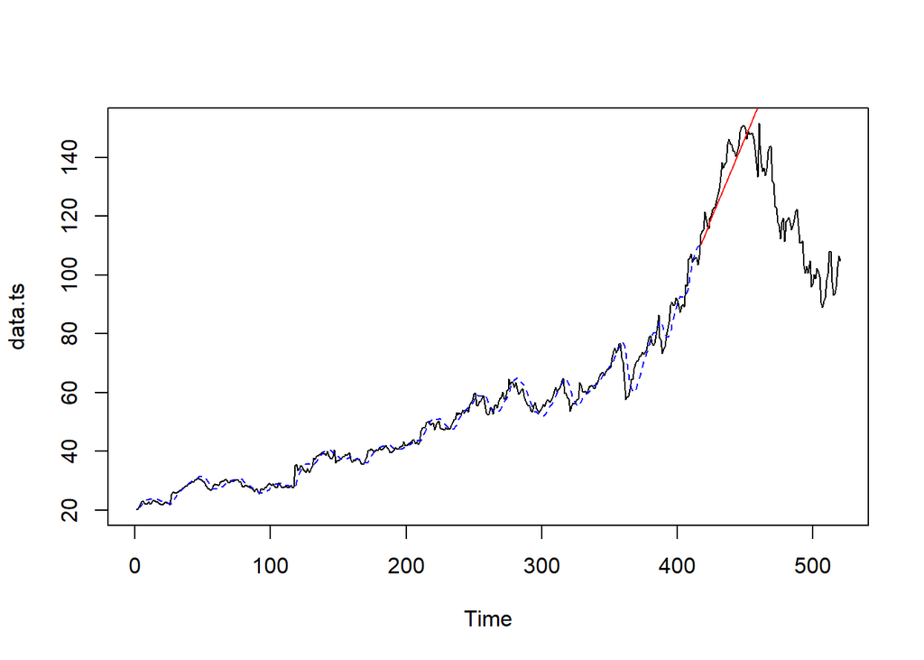

```r
#Visually evaluate the prediction
plot(data.ts)
lines(des.1$fitted[,1], lty=2, col="blue")
lines(ramalandes1$mean, col="red")
```

Untuk mendapatkan nilai parameter optimum dari DES, argumen `alpha` dan `beta` dapat dibuat `NULL` seperti berikut.

```r
#Lamda dan gamma optimum
des.opt<- HoltWinters(train_es.ts, gamma = FALSE)
des.opt
```

```
## Holt-Winters exponential smoothing with trend and without seasonal component.
##
## Call:
## HoltWinters(x = train_es.ts, gamma = FALSE)
##
## Smoothing parameters:
##  alpha: 1
##  beta : 0.005605559
##  gamma: FALSE
##
## Coefficients:
##          [,1]
## a 106.7900000
## b   0.3178052
```

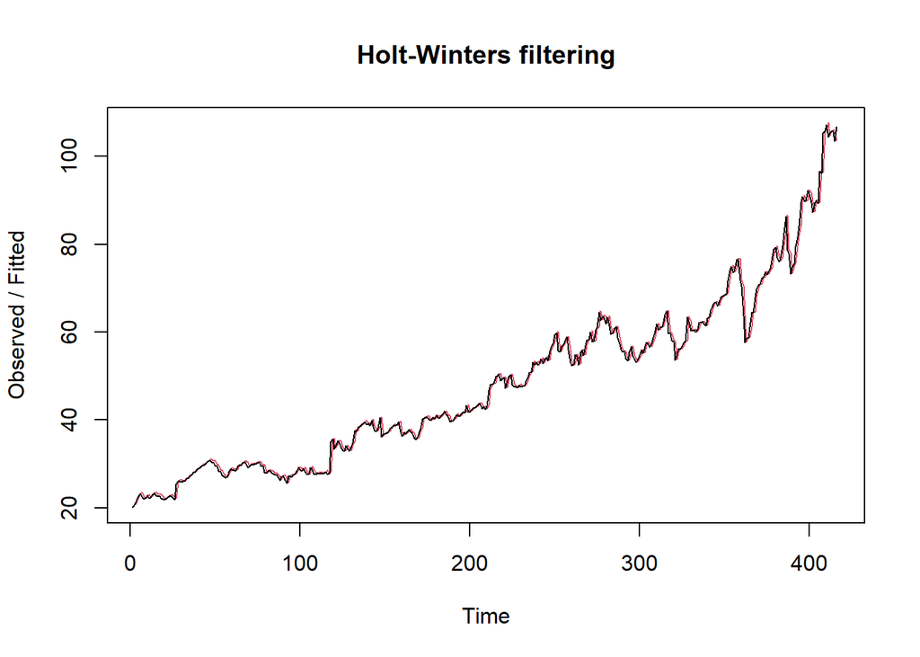

```r
plot(des.opt)
```

```r
#ramalan
ramalandesopt<- forecast(des.opt, h=104)
ramalandesopt
```

```
##     Point Forecast    Lo 80    Hi 80     Lo 95    Hi 95
## 417       107.1078 105.0790 109.1367 104.00494 110.2107
## 418       107.4256 104.5483 110.3029 103.02518 111.8260
## 419       107.7434 104.2096 111.2772 102.33891 113.1479
## 420       108.0612 103.9693 112.1531 101.80319 114.3193
## 421       108.3790 103.7914 112.9667 101.36281 115.3952
## 422       108.6968 103.6573 113.7364 100.98954 116.4041
## 423       109.0146 103.5562 114.4731 100.66666 117.3626
## 424       109.3324 103.4809 115.1840 100.38332 118.2816
## 425       109.6502 103.4266 115.8739 100.13198 119.1685
## 426       109.9681 103.3896 116.5465  99.90718 120.0289
## 427       110.2859 103.3673 117.2044  99.70481 120.8669
## 428       110.6037 103.3575 117.8498  99.52168 121.6856
## 429       110.9215 103.3587 118.4842  99.35527 122.4877
## 430       111.2393 103.3695 119.1090  99.20353 123.2750
```

[output cut: 90 more lines]

Selanjutnya akan dilakukan perhitungan akurasi pada data latih maupun data uji dengan ukuran akurasi SSE, MSE dan MAPE.

#### Akurasi Data Latih

```r
#Akurasi Data Training
ssedes.train1<-des.1$SSE
msedes.train1<-ssedes.train1/length(train_es.ts)
sisaandes1<-ramalandes1$residuals
head(sisaandes1)
```

```
## Time Series:
## Start = 1
## End = 6
## Frequency = 1
## [1]        NA        NA 0.3600000 0.7636000 1.1859360 0.5163674
```

```r
mapedes.train1 <- sum(abs(sisaandes1[3:length(train_es.ts)]/train_es.ts[3:length(train_es.ts)])
                      *100)/length(train_es.ts)

akurasides.1 <- matrix(c(ssedes.train1,msedes.train1,mapedes.train1))
row.names(akurasides.1)<- c("SSE", "MSE", "MAPE")
colnames(akurasides.1) <- c("Akurasi lamda=0.2 dan gamma=0.2")
akurasides.1
```

```
##      Akurasi lamda=0.2 dan gamma=0.2
## SSE                      3403.442518
## MSE                         8.181352
## MAPE                        3.913510
```

```r
ssedes.train2<-des.2$SSE
msedes.train2<-ssedes.train2/length(train_es.ts)
sisaandes2<-ramalandes2$residuals
head(sisaandes2)
```

```
## Time Series:
## Start = 1
## End = 6
## Frequency = 1
## [1]         NA         NA  0.3600000  0.5692000  0.6804240 -0.3575627
```

```r
mapedes.train2 <- sum(abs(sisaandes2[3:length(train_es.ts)]/train_es.ts[3:length(train_es.ts)])
                      *100)/length(train_es.ts)

akurasides.2 <- matrix(c(ssedes.train2,msedes.train2,mapedes.train2))
row.names(akurasides.2)<- c("SSE", "MSE", "MAPE")
colnames(akurasides.2) <- c("Akurasi lamda=0.6 dan gamma=0.3")
akurasides.2
```

```
##      Akurasi lamda=0.6 dan gamma=0.3
## SSE                      1484.070067
## MSE                         3.567476
## MAPE                        2.444689
```

Hasil akurasi dari data latih didapatkan skenario 2 dengan lamda=0.6 dan gamma=0.3 memiliki hasil yang lebih baik. Namun untuk kedua skenario dapat dikategorikan peramalan sangat baik berdasarkan nilai MAPE-nya.

#### Akurasi Data Uji

```r
#Akurasi Data Testing
selisihdes1<-ramalandes1$mean-testing$stock
selisihdes1
```

```
## Time Series:
## Start = 417
## End = 520
## Frequency = 1
##   [1]  -3.5012228  -3.4860086  -2.8807945  -8.0255803  -4.4203661  -0.7751520
##   [7]   0.9500622  -1.4447236  -0.8295095  -1.8542953  -1.4290811  -0.6338670
##  [13]  -1.8186528  -2.5834386  -3.5182245  -6.4730103 -10.2577961  -7.3125820
##  [19]  -7.5873678  -6.9721536 -12.0069395 -12.6317253  -9.9865111  -8.6012970
##  [25]  -5.3660828  -3.8608686  -1.1356545  -1.4104403  -2.2352261  -6.1100120
##  [31]  -6.6747978  -5.8495836  -5.0843695  -2.8291553   1.8160589   0.1312730
##  [37]   2.3764872   3.2217014   4.2369155   7.2021297  11.9573439  17.9625580
##  [43]  23.6777722   6.6029864  15.0182005  22.2734147  26.2286289  26.1738430
##  [49]  29.9290572  28.6042714  23.9194855  23.2846997  24.4799139  37.2151280
##  [55]  39.0203422  48.2555564  49.8007705  55.8859847  57.9811989  63.6764130
##  [61]  59.2116272  58.8768414  67.9220555  62.3772697  62.9924839  63.0076980
##  [67]  65.8029122  69.5181264  69.3233405  68.3685547  66.5837689  66.9489830
##  [73]  73.7741972  80.6594114  81.7346255  82.2198397  91.6250539  95.3702680
##  [79]  94.2554822  97.6106964  95.9459105  95.7111247 105.6163389 105.8315530
##  [85] 103.7367672 106.2319814 103.8571955 105.8424097 108.8076239 118.8928380
##  [91] 121.6280522 120.6332664 120.6084805 115.6136947 114.7089089 108.2941230
##  [97] 109.0793372 120.6945514 126.3897655 126.8749797 125.7501939 119.9954080
## [103] 117.3606222 120.3058364
```

```r
SSEtestingdes1<-sum(selisihdes1^2)
MSEtestingdes1<-SSEtestingdes1/length(testing$stock)
MAPEtestingdes1<-sum(abs(selisihdes1/testing$stock)*100)/length(testing$stock)

selisihdes2<-ramalandes2$mean-testing$stock
selisihdes2
```

```
## Time Series:
## Start = 417
## End = 520
## Frequency = 1
##   [1]  -7.531506  -8.379648  -8.637791 -14.645933 -11.904075  -9.122217
##   [7]  -8.260360 -11.518502 -11.766644 -13.654786 -14.092928 -14.161071
##  [13] -16.209213 -17.837355 -19.635497 -23.453639 -28.101782 -26.019924
##  [19] -27.158066 -27.406208 -33.304350 -34.792493 -33.010635 -32.488777
##  [25] -30.116919 -29.475061 -27.613204 -28.751346 -30.439488 -35.177630
##  [31] -36.605772 -36.643915 -36.742057 -35.350199 -31.568341 -34.116484
##  [37] -32.734626 -32.752768 -32.600910 -30.499052 -26.607195 -21.465337
##  [43] -16.613479 -34.551621 -26.999763 -20.607906 -17.516048 -18.434190
##  [49] -15.542332 -17.730474 -23.278617 -24.776759 -24.444901 -12.573043
##  [55] -11.631185  -3.259328  -2.577470   2.644388   3.876246   8.708104
##  [61]   3.379961   2.181819  10.363677   3.955535   3.707392   2.859250
##  [67]   4.791108   7.642966   6.584824   4.766681   2.118539   1.620397
##  [73]   7.582255  13.604113  13.815970  13.437828  21.979686  24.861544
##  [79]  22.883402  25.375259  22.847117  21.748975  30.790833  30.142691
##  [85]  27.184548  28.816406  25.578264  26.700122  28.801980  38.023837
##  [91]  39.895695  38.037553  37.149411  31.291268  29.523126  22.244984
##  [97]  22.166842  32.918700  37.750557  37.372415  35.384273  28.766131
## [103]  25.267989  27.349846
```

```r
SSEtestingdes2<-sum(selisihdes2^2)
MSEtestingdes2<-SSEtestingdes2/length(testing$stock)
MAPEtestingdes2<-sum(abs(selisihdes2/testing$stock)*100)/length(testing$stock)

selisihdesopt<- ramalandesopt$mean-testing$stock
selisihdesopt
```

```
## Time Series:
## Start = 417
## End = 520
## Frequency = 1
##   [1]  -6.592195  -7.374390  -7.566584 -13.508779 -10.700974  -7.853169
##   [7]  -6.925364 -10.117559 -10.299753 -12.121948 -12.494143 -12.496338
##  [13] -14.478533 -16.040728 -17.772922 -21.525117 -26.107312 -23.959507
##  [19] -25.031702 -25.213896 -31.046091 -32.468286 -30.620481 -30.032676
##  [25] -27.594871 -26.887065 -24.959260 -26.031455 -27.653650 -32.325845
##  [31] -33.688040 -33.660234 -33.692429 -32.234624 -28.386819 -30.869014
##  [37] -29.421208 -29.373403 -29.155598 -26.987793 -23.029988 -17.822183
##  [43] -12.904377 -30.776572 -23.158767 -16.700962 -13.543157 -14.395351
##  [49] -11.437546 -13.559741 -19.041936 -20.474131 -20.076326  -8.138520
##  [55]  -7.130715   1.307090   2.054895   7.342700   8.640505  13.538311
##  [61]   8.276116   7.143921  15.391726   9.049531   8.867337   8.085142
##  [67]  10.082947  13.000752  12.008557  10.256362   7.674168   7.241973
##  [73]  13.269778  19.357583  19.635388  19.323193  27.930999  30.878804
##  [79]  28.966609  31.524414  29.062219  28.030025  37.137830  36.555635
##  [85]  33.663440  35.361245  32.189050  33.376856  35.544661  44.832466
##  [91]  46.770271  44.978076  44.155881  38.363687  36.661492  29.449297
##  [97]  29.437102  40.254907  45.152713  44.840518  42.918323  36.366128
## [103]  32.933933  35.081738
```

```r
SSEtestingdesopt<-sum(selisihdesopt^2)
MSEtestingdesopt<-SSEtestingdesopt/length(testing$stock)
MAPEtestingdesopt<-sum(abs(selisihdesopt/testing$stock)*100)/length(testing$stock)

akurasitestingdes <-
  matrix(c(SSEtestingdes1,MSEtestingdes1,MAPEtestingdes1,SSEtestingdes2,MSEtestingdes2,
           MAPEtestingdes2,SSEtestingdesopt,MSEtestingdesopt,MAPEtestingdesopt),
         nrow=3,ncol=3)
row.names(akurasitestingdes)<- c("SSE", "MSE", "MAPE")
colnames(akurasitestingdes) <- c("des ske1","des ske2","des opt")
akurasitestingdes
```

```
##        des ske1    des ske2     des opt
## SSE  448209.614 60657.62076 68158.06247
## MSE    4309.708   583.24635   655.36599
## MAPE     45.207    17.92688    19.55829
```

#### Perbandingan SES dan DES

```r
MSEfull <-
  matrix(c(MSEtesting1,MSEtesting2,MSEtestingopt,MSEtestingdes1,MSEtestingdes2,
           MSEtestingdesopt),nrow=3,ncol=2)
row.names(MSEfull)<- c("ske 1", "ske 2", "ske opt")
colnames(MSEfull) <- c("ses","des")
MSEfull
```

```
##              ses       des
## ske 1   23805.61 4309.7078
## ske 2   23805.61  583.2464
## ske opt 19953.00  655.3660
```